# DBH estimation in a plantation forest stand using UAV-Based Photogrammetric Point Cloud

FANR 7640 Class Project

Shingo Obata

May 3, 2018

# Overview

## Prerequisite

Following description in this paper assumes that readers has basic knowledge of [R](https://cran.r-project.org/). If you are new to [R](https://cran.r-project.org/), following websites are helpfult to quickly dive into [R](https://cran.r-project.org/).

- (https://www.datacamp.com/courses)
- (https://cran.r-project.org/doc/manuals/r-release/R-intro.html)
- (https://www.rstudio.com/online-learning/)

# Study area and data used

The study area is 1.8 acre of a stand located in Whitehall Forest, Athens, GA.

[figure not shown]

Point cloud data of the study area is acquired by using a drone in 2017. The point cloud is the spatial dataset comprised of 3D points. It is collected by the sensor that emits a pulse of energy and records the time of response. The time is called as TWTT, two way travel time (https://www.usna.edu/Users/oceano/pguth/md_help/html/pt_clouds.htm). From the point cloud data points which were collected by the sensor equipped to the drone ([DJI Mavic Pro Drone](https://www.dji.com/newsroom/news/dji-revolutionizes-personal-flight-with-new-mavic-pro-drone)), [LAS data](http://desktop.arcgis.com/en/arcmap/10.3/manage-data/las-dataset/what-is-a-las-dataset-.htm), [orthophoto](https://online.wr.usgs.gov/ngpo/doq/doq_basics.html) and [DTM](https://en.wikipedia.org/wiki/Digital_elevation_model) data are processed. these 3 data are used for the analysis.

# Preparation

## Package

This file omits the code `install.packages()`. Please install the following packages before running the code below.

- lidR
- raster

If you have not installed `lidR` package, install it first.

```r
library(lidR)
library(raster)
library(dplyr)
library(rgl)
library(BiocManager)
# BiocManager::install("EBImage")
library(EBImage)
library(rmarkdown)
# source("http://bioconductor.org/biocLite.R")
# biocLite("EBImage")# used for lastrees function
load("pointCloudData_seg.RData")
```

## Read LAS data

First of all read out las file using `readLAS` function.

```r
pcloud=readLAS("PMRC_pointcloud.las")
summary(pcloud@data$Z)
```

[output not shown]

You can view 3D plot using `plot` function in `lidR` package.

```r
# plot(pcloud)
```

`plot(pcloud)` isn’t shown in this paper because it requires long processing time to render the 3-D interactive image. If you want to see how the point cloud data looks like, you can just run `plot(pcloud)` from your R console.

# NED data as DEM

The *las* data in this analysis does not have classification data, which distinguishes the ground point and another point. So we need to import the data to get the height of ground data. In this project, I am going to use 10m NED data.

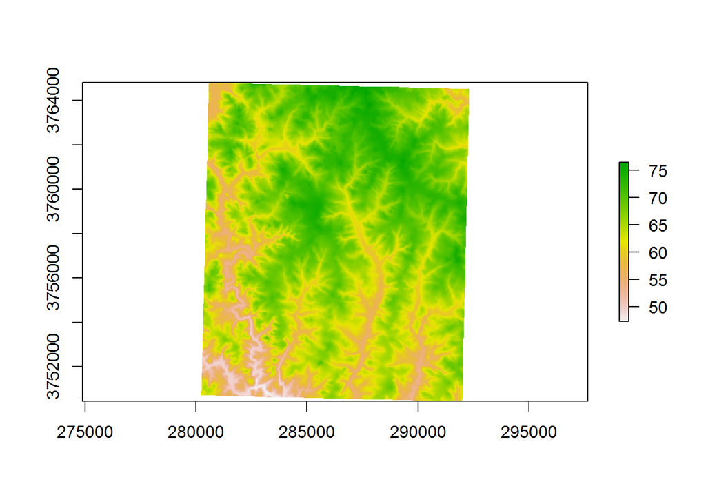

```r
ned=raster("ned/ned10m33083h3_meter.tif")
plot(ned)
```

I downloaded this data from [NRCS gateway](https://datagateway.nrcs.usda.gov/). Then, convert the unit of measurement from feet to the meter so that point cloud data and NED get the same unit.

`lasnormalize` function takes the difference between the point cloud and reference data. In this project, reference data is NED.

```r
pcloud=lidR::lasnormalize(pcloud,ned)
hist(pcloud@data$Z)
```

[output not shown]

49063 points below 0 meter found. One possible solution is to remove points that have negative value in z column.

# Canopy segmentation

`grid_canopy` applies focal statistics to the 3D point cloud. The function detects the largest value in the moving window of 1 meter. As an output, `grid_canopy` Creates a canopy surface model using a LiDAR point cloud. For each pixel, the function returns the highest point found (point-to-raster). You can try the size of the moving window to get a better estimation.

```r
mov0.5 <- lidR::grid_canopy(pcloud, 1,pitfree())
mov0.5_ras=as.raster(mov0.5)
plot(mov0.5)
```

[output not shown]

[`lastrees`](https://www.rdocumentation.org/packages/lidR/versions/1.2.1/topics/lastrees) function performs individual tree segmentation using one of the available algorithms. In this code, I use `li2012` as a segmentation algorithm. It is based on the Bioconductor package `EBIimage`. You need to install this package to run this method. `lastrees` function appends treeID as a new column to point cloud data. Depending on the computing capability of your machine, it may take 5-10 minutes to complete this chunk.

```r
pcloud=lastrees(pcloud, li2012(R = 3, speed_up = 5))
save(pcloud,file="pointCloudData_seg.RData")
```

```r
summary(pcloud)
```

```
## class        : LAS (LASF v1.2)
## point format : 2
## memory       : 660.1 Mb
## extent       :281914.4, 282036, 3751046, 3751170 (xmin, xmax, ymin, ymax)
## coord. ref.  : +proj=utm +zone=17 +datum=NAD83 +units=m +no_defs +ellps=GRS80 +towgs84=0,0,0
## area         : 9958.732 m²
## points       : 7.21 million points
## density      : 723.98 points/m²
## names        : X Y Z Intensity ReturnNumber NumberOfReturns ScanDirectionFlag EdgeOfFlightline Classification Synthetic_flag Keypoint_flag Withheld_flag ScanAngleRank UserData PointSourceID R G B treeID Zref
## File signature:           LASF
## File source ID:           1
## Global encoding:
##  - GPS Time Type: GPS Week Time
##  - Synthetic Return Numbers: no
##  - Well Know Text: CRS is GeoTIFF
##  - Aggregate Model: false
## Project ID - GUID:        00000000-0000-0000-0000-000000000000
## Version:                  1.2
## System identifier:        Agisoft PhotoScan
## Generating software:      Agisoft PhotoScan
## File creation d/y:        89/2018
## header size:              227
## Offset to point data:     760
## Num. var. length record:  3
## Point data format:        2
## Point data record length: 26
## Num. of point records:    7209946
## Num. of points by return: 7209946 0 0 0 0
## Scale factor X Y Z:       0.001 0.001 0.001
## Offset X Y Z:             281000 3751000 0
## min X Y Z:                281914.4 3751046 -27.94
## max X Y Z:                282036 3751170 31.16
## Variable length records:
##    Variable length record 1 of 4
##        Description:
##        Tags:
##           Key 1024 value 1
##           Key 1025 value 1
##           Key 2048 value 4269
##           Key 2049 value 0
```

[output cut: 16 more lines]

[output not shown]

# Estimating height, crown diameter, and location of individual trees

From here, I start estimation. I create new `SpatialPointsDataFrame` which contains information about - Crown diameter (m) - Height (m) - Stem Location (lat,lon) - DBH (cm)

## Tree location estimation

Tree position is specified by taking the mean of x and y.

## Height estimation

The highest point for each treeID represents the height of each tree. It is assigned to all the points under the same treeID as a new column.

```r
crown.raw=pcloud@data%>%group_by(treeID)%>%summarize(X.loc=mean(X),
                                                   Y.loc=mean(Y),
                                                   H=max(Z),
                                                    xmin=min(X),
                                                    xmax=max(X),
                                                    ymin=min(Y),
                                                    ymax=max(Y))
```

`summarize` function from `dplyr` package

## Crown diameter estimation

It is assumed that the crown has a circle shape. Thus, the crown diameter is estimated by the following formula.

$$CD=\{(x_{max}-x_{min})+(y_{max}-y_{min})\}/2$$
where,

$CD$: Crown diameter (m)

$x_{max}$: maximum value of latitude

$x_{min}$: minimum value of latitude

$y_{max}$: maximum value of longitude

$y_{min}$: minimum value of longitude

```r
crown.raw$xlen=crown.raw$xmax-crown.raw$xmin
crown.raw$ylen=crown.raw$ymax-crown.raw$ymin
crown.raw$diam=(crown.raw$xlen+crown.raw$ylen)/2
```

## DBH estimation

DBH is not directly measurable from the UAS data. To measure DBH from the given data, one solution is to apply the allometric equation to height and crown diameter. In this paper, I refer to Jucker et al. (2016) to acquire the allometric function of DBH.

$$D_{pred}=0.557 \times (H \times CD)^{0.809} \times \exp(0.0056^2/2)$$
where,

$D_{pred}:$ Predicted DBH

$H:$ Estimated height

$CD:$ Estimated crown diameter

```r
crown.raw$dbh=0.557 * ((crown.raw$H * crown.raw$diam)^0.809) * exp((0.0056^2)/2)
crown=SpatialPointsDataFrame(coords=crown.raw[,2:3],data=as.data.frame(crown.raw[4:11]))
```

The `crown` object is the `SpatialPointsDataFrame` that contains the highest points of individual trees.

The following code shows the highest points of individual trees overlayed on orthophoto.

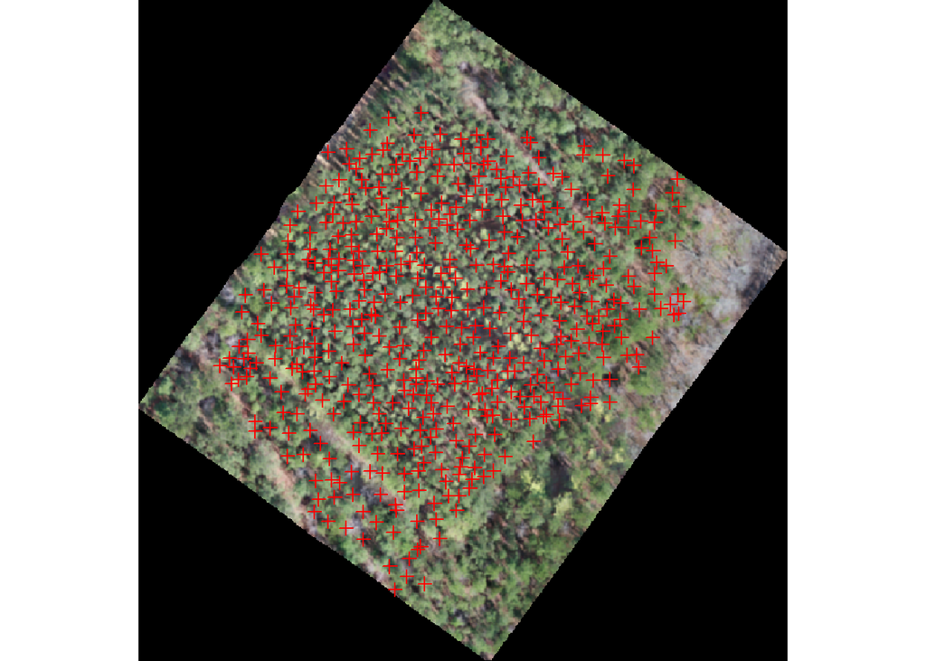

```r
ortho=stack("PMRC_ortho.tif")
plotRGB(ortho)
plot(crown,add=T,col="red")
```

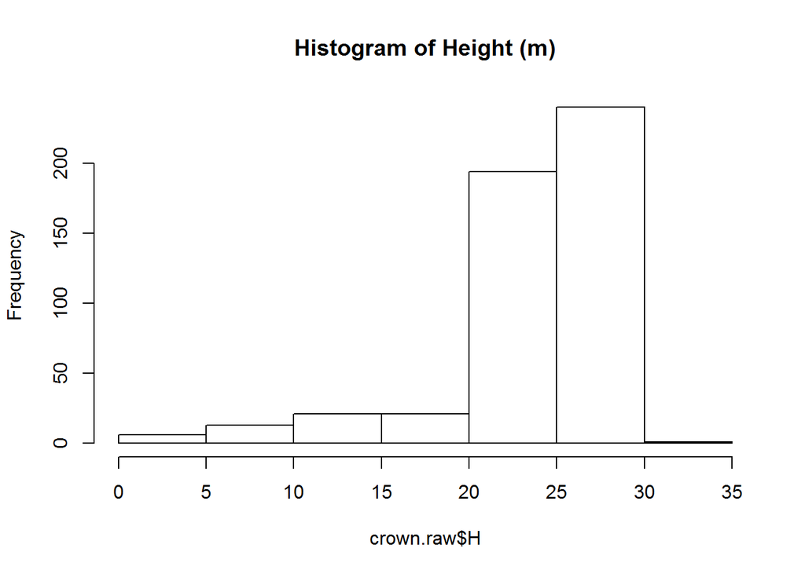

```r
hist(crown.raw$H,main="Histogram of Height (m)")
```

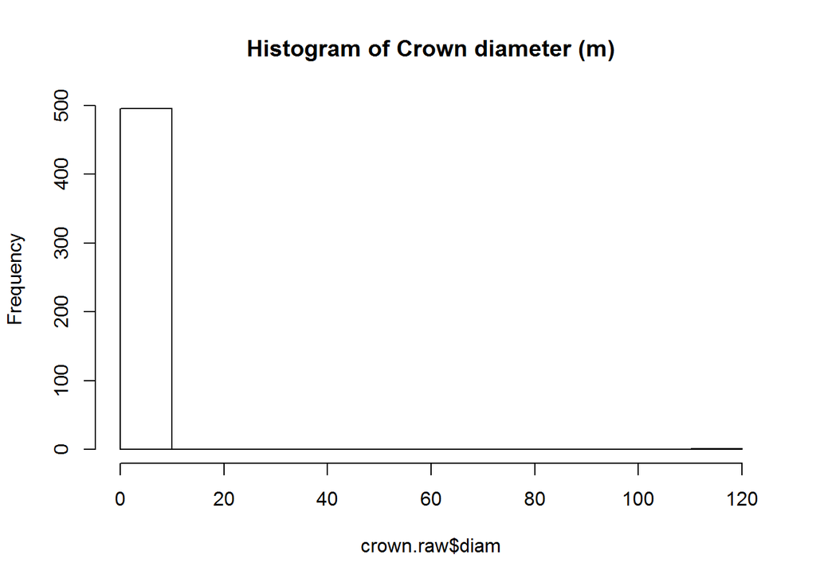

```r
hist(crown.raw$diam,main="Histogram of Crown diameter (m)")
```

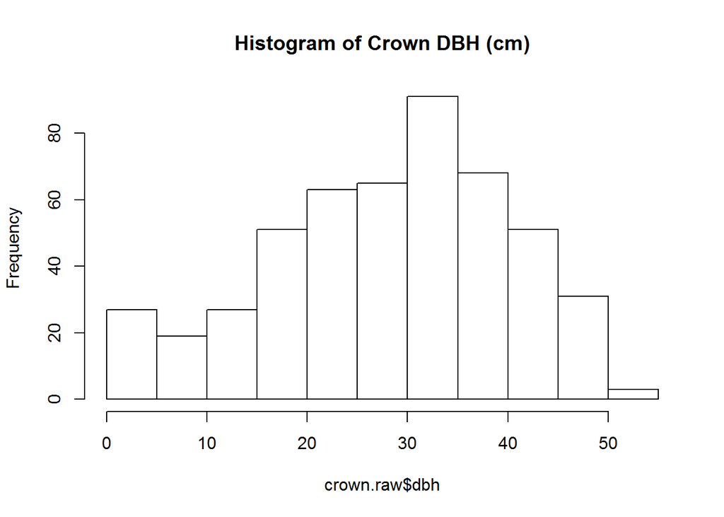

```r
hist(crown.raw$dbh,main="Histogram of Crown DBH (cm)")
```

Finally, following code shows 3-D plot and height.

```r
#
# points3d(crown@coords[,1],crown@coords[,2],crown@data$H)# this code adds the highest point of each tree to the base plot.
x=plot(pcloud)
add_treetops3d(x,crown,z="H")
```

# Conclusion

# Reference

- Jucker Tommaso, Caspersen John, Chave J?r?me, Antin C?cile, Barbier Nicolas, Bongers Frans, . Coomes David A. (2016). Allometric equations for integrating remote sensing imagery into forest monitoring programs. Global Change Biology, 23(1), 177-190. https://doi.org/10.1111/gcb.13388
- Ota, T., Ogawa, M., Mizoue, N., Fukumoto, K., & Yoshida, S. (2017). Forest Structure Estimation from a UAV-Based Photogrammetric Point Cloud in Managed Temperate Coniferous Forests. Forests, 8(9), 343. https://doi.org/10.3390/f8090343